# R Notebook

Opgave 7.7. Bemærk: Figuren nederst til højre er lidt atypisk i forhold til hvad man ser i praksis, men overvej alligevel hvad “der er galt” med figuren.

Opgave 7.2. To ekstra spørgsmål: Bestem et 95% konfidensinterval og et 95% prædiktionsinterval svarende til værdien 8 for radioact. Hvad er fortolkningen af de to intervaller? NB: Det er fint at beregne intervallerne på log-skala, men du bør tænke over hvilken betydning det har for fortolkningen, hvis man ønsker at regne resultaterne tilbage til den oprindelige skala. For hvilken værdi af radioact vil man forvente at få en tumorvægt på 0.2? Opgave 7.4.

# Opgave 7.7

Figur 1: Problem with variance homogeneity. Positiv tragt form

Figur 2: Problem conserning the mean. Der er en systematisk kurveformet afvigelse fra gennemsnittet. Der skulle nok være fittet en kubisk model.

Figur 3: Den er fjong

Figur 3: Den er ikke normaltfordelt ud, vi ville forvenete at der var flere værdi omkring 0.

# Opgave 7.2

## Opgave 1

Vi vil gerne sige noget om vægten ud fra radiokativiteten, så vi vælger vægt som responsvariabel og radioaktivitet som forklarende variabel.

```r
library("isdals")
library("ggplot2")
data("cancer2")

head(cancer2, n = 3)
```

|  | id | tumorwgt | radioact |
| --- | --- | --- | --- |
| 1 | 1 | 0.04 | 0.779 |
| 2 | 2 | 0.06 | 2.078 |
| 3 | 3 | 0.07 | 1.299 |

```r
linreg <- lm(tumorwgt ~ radioact, data = cancer2) # Fit
summary(linreg)
```

```
Call:
lm(formula = tumorwgt ~ radioact, data = cancer2)

Residuals:
      Min        1Q    Median        3Q       Max
-0.208387 -0.056239  0.004903  0.046980  0.252811

Coefficients:
             Estimate Std. Error t value Pr(>|t|)
(Intercept) -0.002324   0.056306  -0.041    0.968
radioact     0.048071   0.008317   5.780 2.82e-05 ***
---
Signif. codes:  0 ‘***’ 0.001 ‘**’ 0.01 ‘*’ 0.05 ‘.’ 0.1 ‘ ’ 1

Residual standard error: 0.1152 on 16 degrees of freedom
Multiple R-squared:  0.6761,    Adjusted R-squared:  0.6559
F-statistic: 33.41 on 1 and 16 DF,  p-value: 2.818e-05
```

```r
confint(linreg)
```

```
                  2.5 %     97.5 %
(Intercept) -0.12168745 0.11704031
radioact     0.03043944 0.06570265
```

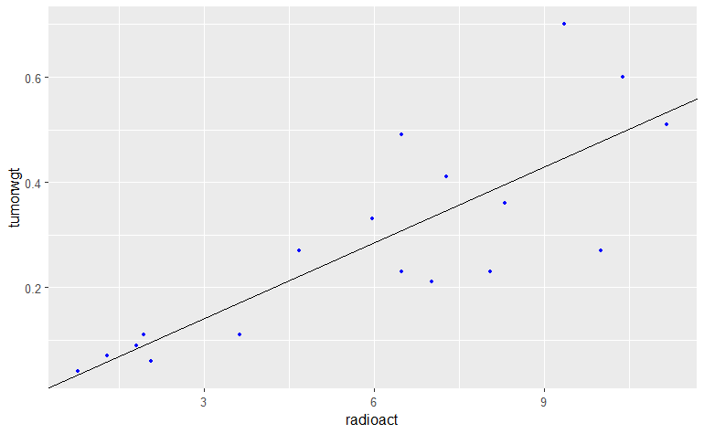

```r
alpha <- as.numeric(coef(linreg)[1]) # Intercept
beta <- as.numeric(coef(linreg)[2]) # Slope

ggplot(data = cancer2, aes(x = radioact, y = tumorwgt)) +
  geom_point(color = "blue", size = 1) + # Scatter
  geom_abline(slope = beta, intercept = alpha) # line
```

## Opgave 2

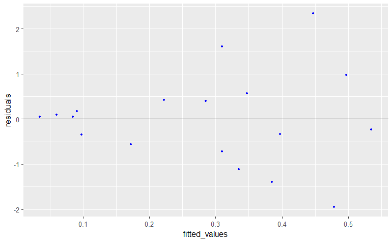

```r
cancer2$fitted_values <- fitted(linreg)
cancer2$residuals <- rstandard(linreg)

ggplot(data = cancer2, aes(x = fitted_values, y = residuals)) +
  geom_point(color = "blue", size = 1) + # Scatter
  geom_abline(slope = 0, intercept = 0) # line
```

Den tragtformede fordeling af residualsene tyder på at der er noget galt med antagelsen om varians homonigitet.

## Opgave 3

```r
linreg_log <- lm(log(tumorwgt) ~ radioact, data = cancer2) # Fit
summary(linreg_log)
```

```
Call:
lm(formula = log(tumorwgt) ~ radioact, data = cancer2)

Residuals:
     Min       1Q   Median       3Q      Max
-0.67270 -0.28773 -0.02579  0.32752  0.71066

Coefficients:
            Estimate Std. Error t value Pr(>|t|)
(Intercept)  -2.8824     0.1950 -14.783 9.51e-11 ***
radioact      0.2246     0.0288   7.797 7.72e-07 ***
---
Signif. codes:  0 ‘***’ 0.001 ‘**’ 0.01 ‘*’ 0.05 ‘.’ 0.1 ‘ ’ 1

Residual standard error: 0.3989 on 16 degrees of freedom
Multiple R-squared:  0.7917,    Adjusted R-squared:  0.7786
F-statistic:  60.8 on 1 and 16 DF,  p-value: 7.722e-07
```

```r
confint(linreg_log)
```

```
                 2.5 %     97.5 %
(Intercept) -3.2957941 -2.4690912
radioact     0.1635237  0.2856385
```

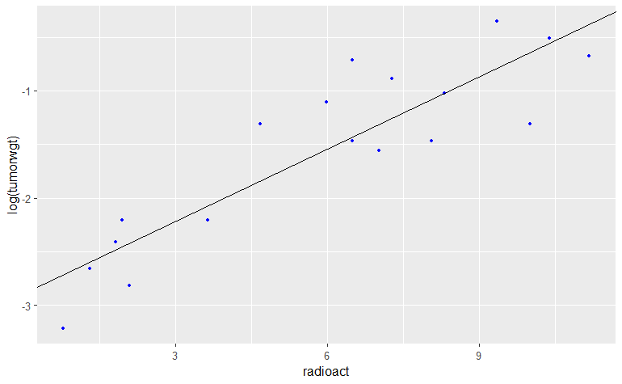

```r
alpha <- as.numeric(coef(linreg_log)[1]) # Intercept
beta <- as.numeric(coef(linreg_log)[2]) # Slope

ggplot(data = cancer2, aes(x = radioact, y = log(tumorwgt))) +
  geom_point(color = "blue", size = 1) + # Scatter
  geom_abline(slope = beta, intercept = alpha) # line
```

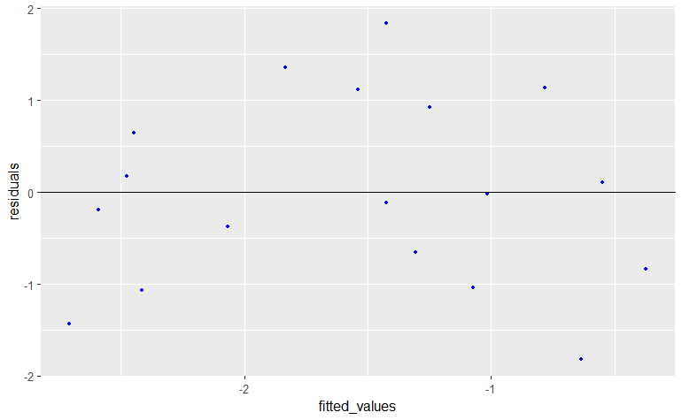

```r
cancer2$fitted_values <- fitted(linreg_log)
cancer2$residuals <- rstandard(linreg_log)

ggplot(data = cancer2, aes(x = fitted_values, y = residuals)) +
  geom_point(color = "blue", size = 1) + # Scatter
  geom_abline(slope = 0, intercept = 0) # line
```

Vi løser problemet med inhomoginietet ved at log transformere, således at høje værdi bliver mindkes gradvist mere end de lave værdier.

## opgave 4

```r
pred_8 <- predict(linreg_log, newdata = data.frame(radioact = 8), interval = "c")
exp(pred_8)
```

```
        fit       lwr       upr
1 0.3376336 0.2666605 0.4274965
```

Vi forventer den kommer til at veje 0.34

## opgave 5

```r
predict_int_c <- predict(linreg_log, newdata = data.frame(radioact = 8), interval = "c")
predict_int_p <- predict(linreg_log, newdata = data.frame(radioact = 8), interval = "p")

predict_int_c
```

```
        fit       lwr        upr
1 -1.085794 -1.321779 -0.8498092
```

```r
predict_int_p
```

```
        fit       lwr        upr
1 -1.085794 -1.963738 -0.2078501
```

```r
cat("Lower // Upper \n")
```

```
Lower // Upper
```

```r
exp(predict_int_c[2])
```

```
[1] 0.2666605
```

```r
exp(predict_int_c[3])
```

```
[1] 0.4274965
```

```r
cat("\n")
```

```r
cat("Lower // Upper \n")
```

```
Lower // Upper
```

```r
exp(predict_int_p[2])
```

```
[1] 0.1403329
```

```r
exp(predict_int_p[3])
```

```
[1] 0.8123288
```

Den bedste prediktion er middelværdien, men når vi transformere data tilbage, så har vi medianen i stedet. Fordi vi ikke har outlierne til at trække i middelværdien.

Prediktions intervallet er større end konfidensintervallet end for gennemsnit, fordi vi tager højde for afvigelsen fra gennesnittet (spredning = 1)

Middelværdien for den logaritmiske skala, svare til medianen når vi transformere tilbage til den originale skala.

## Opgave 6

```r
beta0 <- coef(linreg_log)[1]  # Intercept
beta1 <- coef(linreg_log)[2]  # Slope

target_y = log(0.2)
x_value = (target_y - beta0) / beta1

print(x_value)
```

```
(Intercept)
   5.668353
```

# Opgave 7.4

## Opgave 1

```r
data(pillbug)

head(pillbug, n = 3)
```

|  | time | group |
| --- | --- | --- |
| 1 | 23 | Light |
| 2 | 12 | Light |
| 3 | 29 | Light |

```r
NA
```

```r
# Make a control group
pillbug$group <- relevel(pillbug$group, ref="Control")

# Log transformed variable
pillbug$log_time <- log(pillbug$time)
```

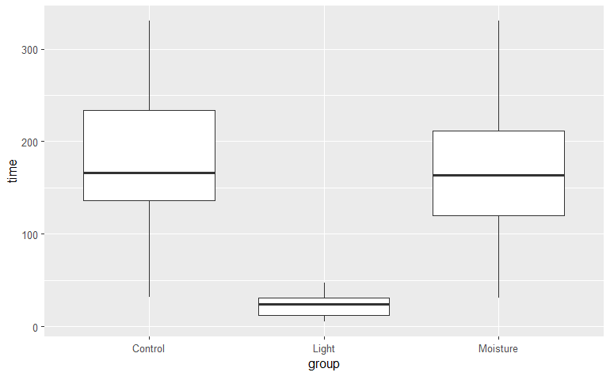

```r
ggplot(data = pillbug, aes(x = group, y = time)) +
  geom_boxplot(outliers = TRUE) +
  xlab("group") + ylab("time")
```

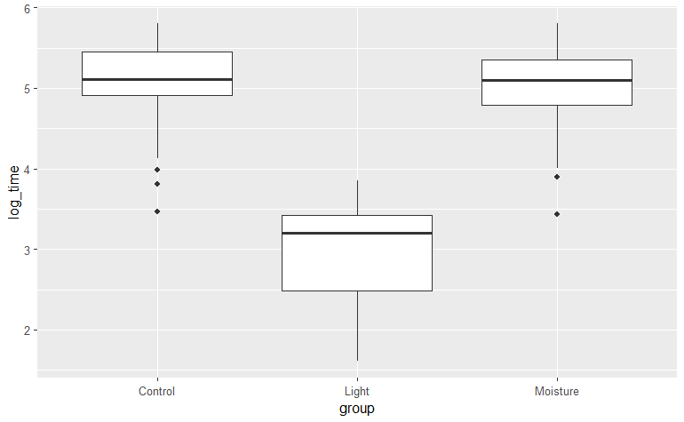

```r
ggplot(data = pillbug, aes(x = group, y = log_time)) +
  geom_boxplot(outliers = TRUE) +
  xlab("group") + ylab("log_time")
```

## Opgave 2

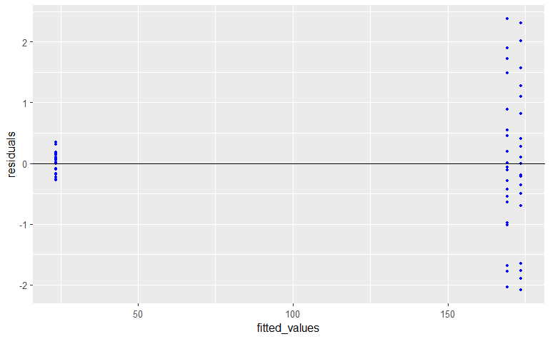

```r
m1 <- lm(time ~ group, data = pillbug)

pillbug$fitted_values <- fitted(m1)
pillbug$residuals <- rstandard(m1)

ggplot(data = pillbug, aes(x = fitted_values, y = residuals)) +
  geom_point(color = "blue", size = 1) + # Scatter
  geom_abline(slope = 0, intercept = 0) # line
```

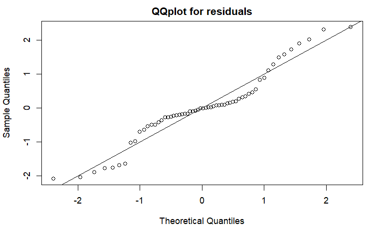

```r
qqnorm(pillbug$residuals, main = "QQplot for residuals")
abline(a = 0, b = 1)
```

Vi ser en systematisk afvigelse fra QQplot, hvilket tyder på at restledene ikke er normalt fordelt

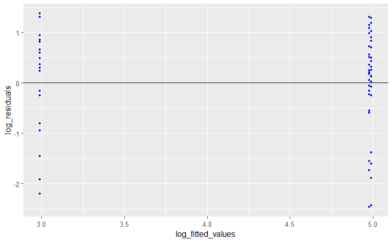

```r
m2 <- lm(log_time ~ group, data = pillbug)

pillbug$log_fitted_values <- fitted(m2)
pillbug$log_residuals <- rstandard(m2)

ggplot(data = pillbug, aes(x = log_fitted_values, y = log_residuals)) +
  geom_point(color = "blue", size = 1) + # Scatter
  geom_abline(slope = 0, intercept = 0) # line
```

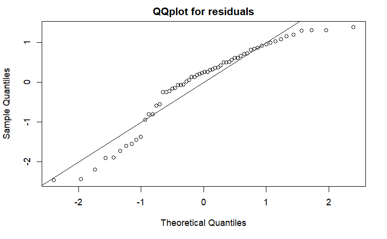

```r
qqnorm(pillbug$log_residuals, main = "QQplot for residuals")
abline(a = 0, b = 1)
```

Det er fint nok.

## Opgave 4

Det ser ikke ud til at der er problemer med homogonitets antagelsen ift. residual plottet for den logtransformeret data. Dertil ser vi i mindre grad en systematisk afvigelse fra den ligefrem propotionale linje i QQplotet. Vi havde ret i opgave 1 :)

## Opgave 5

Vi bruger den logtransformeret model, da den stemmer bedre overens med model antagelserne for ANOVA.

```r
summary(m2)
```

```
Call:
lm(formula = log_time ~ group, data = pillbug)

Residuals:
    Min      1Q  Median      3Q     Max
-1.5454 -0.2037  0.1510  0.4448  0.8602

Coefficients:
              Estimate Std. Error t value Pr(>|t|)
(Intercept)    4.99207    0.14378  34.720  < 2e-16 ***
groupLight    -2.00211    0.20334  -9.846 6.61e-14 ***
groupMoisture -0.01266    0.20334  -0.062    0.951
---
Signif. codes:  0 ‘***’ 0.001 ‘**’ 0.01 ‘*’ 0.05 ‘.’ 0.1 ‘ ’ 1

Residual standard error: 0.643 on 57 degrees of freedom
Multiple R-squared:  0.6926,    Adjusted R-squared:  0.6819
F-statistic: 64.23 on 2 and 57 DF,  p-value: 2.498e-15
```

Vi opstiller en 0-hypotese om at der ikke er forskel mellem kontrol og light, $H_0 : \alpha_1 - \alpha_2 = 0$, vi får en meget lille p-værdi, hvilket betyder at vi forkaster hypotesen. Data taler altså for der er en indflydelse hvis de bliver eksponeret til lys.

## Opgave 6

```r
confint(m2)
```

```
                   2.5 %     97.5 %
(Intercept)    4.7041572  5.2799872
groupLight    -2.4092865 -1.5949399
groupMoisture -0.4198323  0.3945143
```

## Opgave 7

```r
log(50)
```

```
[1] 3.912023
```

```r
predict(m2, newdata = data.frame(group = "Light"), interval = "p")
```

```
       fit      lwr      upr
1 2.989959 1.670567 4.309351
```

```r
log(50)
```

```
[1] 3.912023
```

Intervallet vil indeholde 95 % af nye/fremtidige målinger. Da 3.912 er indenfor intervallet er det ikke en uanmindelig værdi.